# What to Do Before Fitting

A document to summarize which variables we are interested in including in the model. All of you can make edits to the file/comment on whether my justification is appropriate. I did consider Melody’s list before compiling these.

Essential idea is that I divide the variables into three groups: 1. Observed varaibles relating to subjective measure of alcohol consumption beliefs; 2. Observed variables relating to objective measure of alcohol consumption; 3. Demographic predictors to be adjusted for.

1. and 2. consist of questions from Sections B and C, except a few that I think would not help us much with noisy measurements. I mainly skipped the questions in Section D, even though they must provide valuable information about the social network structure, simply to make our lives easier. Maybe you could add them in the analysis, given that we have enough time and resources.

For 3., I excluded any variables that may be considerd “confounders,” in that even if the survey questions mainly relate to demographics, they can still have substantial correlation with belief questions in their subjective phrasing. Also I tried to restrict my focus to variables that can be as accurately measured by this questionnaire as possible, as I want to place restrictions on how many latent layers our model will have before presentation. Many questions in Section F and G have thus been omitted.

# 1. Subjective Questions

```
- B1

- B3

- B4

- B5

- B7A ~ B7E.

- B19

- B21A ~ B21I.
```

# 2. Objective Questions

```
- C1

- C2

- C3 ~ C6. Note these questions are for respondents who either responded >1 to C1 or to C2 (or both). Also, a separabe variable called C6_FEE exists for response 7 to C6.

- C7

- C9

- C10

- C11 ~ C15. Note these questions are for respondents who responded >3 for C10.

- C16 is for respondents meeting the above condition + less than age 21 (A1 response < 21).

- C17 ~ C21. Note these questions are for those who responded >2 for C10.

- C22A ~ C22S.
```

# 3. Demographic Predictors

```
- A1

- A2

- A3

- A4. Note there is a sub-question A4A for responses 2 and 3.

- A5

- A6. Note there is a sub-question A6A for responses 5 and 6.

- A7A ~ A7D.

- A8A ~ A8I.

- F5

- G1

- G2

- G3 (Race: there exist respondents who chose multiple responses, even though the question asked to choose one.)

- G4

- G5A ~ G5B.

- G7

- G8

- G13

- G19A ~ E. (Whether a respondent has complete previous-year survey or not)
```

# Overview of Response rates

First, we may want to exclude from our sample those participants who have not responded to too many questions. Necessary adjustments are done to account for questions that allow multiple responses, or only target certain participants, etc, to obtain “true” missingness rates. The `missing_a` object refers to a binary matrix of missingness indices. **Categorical variables are excluded, as they cannot be dealt very well as endogenous variables in our SEM implementation (B7, C3, C15, C16).**

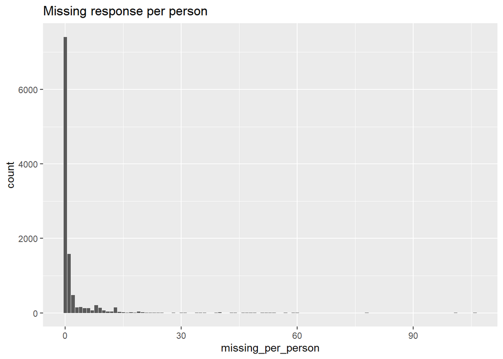

It will be safe to exclude a number of participants who have filled out too few a questions on the survey based on the histogram.

Examining how many respones are missing for each of the questions, correcting for the fact that many questions ask only a part of the entire participants to respond.

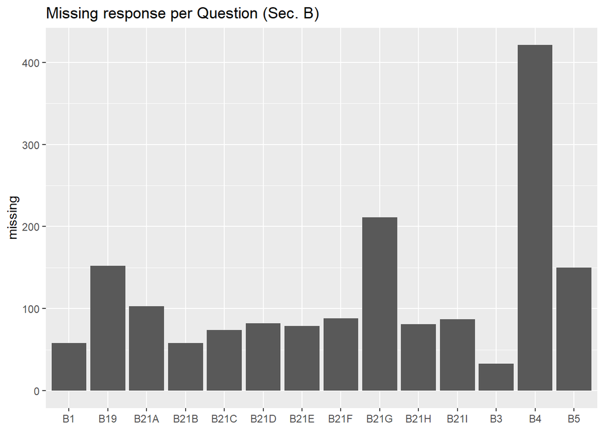

[figure not shown]

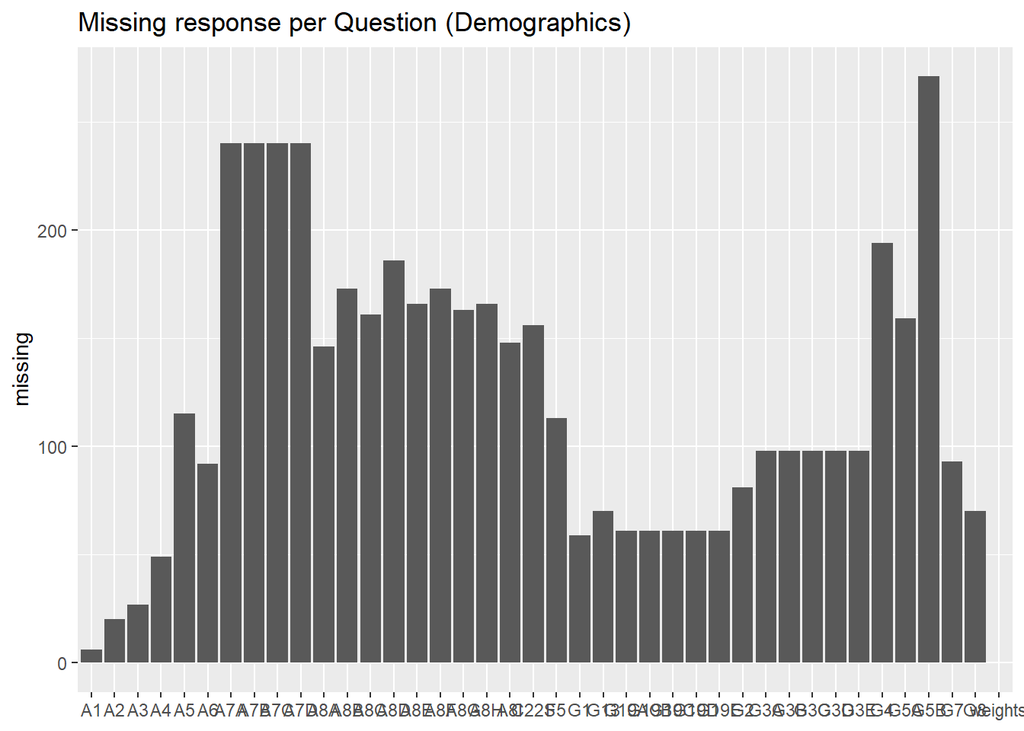

Question B4 had the most missing response (“Do you agree with the way your college is dealing with alcohol?”), followed by C5 (“How long did it take you to consume the number of drinks indicated in C4?”), and subquestions for C17 (“Since the beginning of the school year, how often has drinking caused … [problems]?”).

# Encoding of responses

To facilitate the interpretation of the model for ordinal variables, any response options that were not consistently coded are recoded in the following direction:

```
* Section B: More stringent policy beliefs (Less) -> Lenient policy beliefs (More)

* Section C: Less alcohol consumption (Less) -> More consumption (More)
```

Responses to questions B7, C3, C15, and C16 are categorical. For questions C20 and C22, direction of encoding is Not At All Important (less reliance) -> Very Important (more reliance).

I believe this should offer us all a common starting point.

# Dealing with Missing cases and Unreliable responses

Excluding all observations that have missing values in predictors seems like a convenient starting point. There are 1330 cases to be excluded from the analysis. As below, further cases may need to be removed since we do not have enough information about which population group a participant belongs to for the indirect response variables. Alternatively, we can do MICE. Some variable mutation (previous survey experience as numeric, etc.) follows in the code.

On the other hand, there is another data processing issue for unreliable responses. Take A7, which allows multiple responses. There are at least 30 people who responded they live alone *and* also live with someone else (roommate/spouse/parents, etc.). Part of this is a systematic misunderstanding of the survey instructions: there are at least 329 participants who thought even though they responded “None” to both C1 and C2, they still had to respond to C6. The unreliability of some of these responses must be accounted for. One approach would be first sub-dividing our sample into different population groups, and for each group fitting a *group-wise* SEM. Fitting can be an issue, but this we can think of later. This also implies that when we subdivide the sample, there will be some cases excluded because their responses are missing for precisely the questions that allow us to classify their population group (56 in this case).

So in total, we have 9574 cases for the analysis.